# Bias-estimation demo

Michael McLaren

2019-02-15

```r
library(tidyverse)
library(ggbeeswarm)
devtools::load_all(here::here())
```

```
#> Loading BiasManuscript
```

```r
set.seed(1)
```

Bias for 5 fake taxa:

```r
K <- 5
taxa <- paste0("T", seq(K))
bias <- tibble(Taxon = taxa, Bias = exp(rnorm(K, 0, 2))) %>%
    mutate(
        Bias = center_elts(Bias),
    )
bias
```

```
#> # A tibble: 5 x 2
#>   Taxon   Bias
#>   <chr>  <dbl>
#> 1 T1     0.221
#> 2 T2     1.11
#> 3 T3     0.145
#> 4 T4    18.8
#> 5 T5     1.49
```

## Experiment where all samples contain all taxa

Let’s first consider an experiment where all samples have all taxa. I will draw the actual abundances as iid from an exponential distribution, and take the residual error to be iid log-normal with an sd on the log scale of 0.5.

```r
N <- 10
samples <- paste0("S", seq(N))
exp1 <- crossing(Sample = samples, Taxon = taxa) %>%
    left_join(bias, by = "Taxon")
exp1 <- exp1 %>%
    mutate(
        Actual = rexp(n(), 1),
        Noise = exp(rnorm(n(), sd = 0.5)),
        Observed = Actual * Bias * Noise
    ) %>%
    group_by(Sample) %>%
    mutate_at(vars(Actual, Noise, Observed), center_elts) %>%
    ungroup
```

The `center_elts` function normalizes the vectors by the geometric mean of their elements.

These samples have varying actual compositions, but the compositional differences (Observed/Actual) will appear consistent when normalized in this manner:

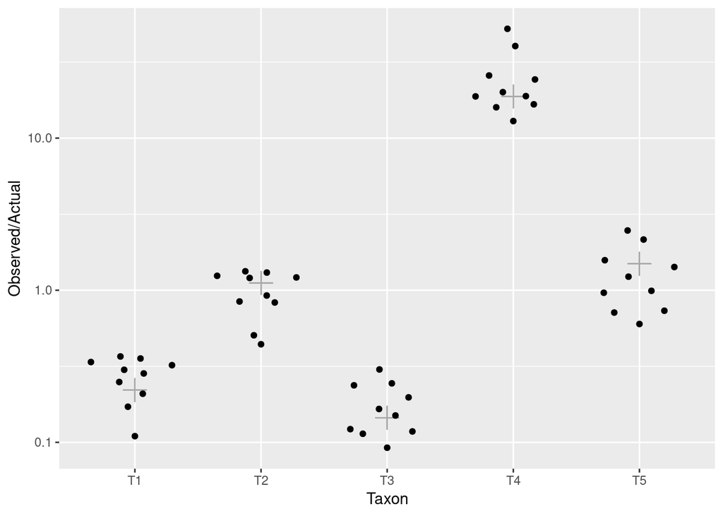

```r
p <- ggplot(exp1, aes(Taxon, Observed / Actual)) +
    geom_point(aes(y=Bias), shape = 3, size = 5, color = "darkgrey") +
    geom_quasirandom() +
    scale_y_log10()
p
```

The systematic deviation from 1 corresponds to the Bias, with the residual variation due to the Noise factors.

The `estimate_bias` function requires a data frame with Sample, Actual, and Observed columns. It does not depend on how the abundances are normalized (e.g. as proportions, or as above are both fine). It has two methods, the “center” method, which estimates the bias by the compositional mean of the observed errors, and the “rss” method, which estimates the bias by minimizing the sum of squares of the residual errors as measured in the Aitchison geometry. Here, both methods can be applied and give the same answer

```r
est1 <- bias %>%
    left_join(estimate_bias(exp1, method = "center"), by = "Taxon") %>%
    left_join(estimate_bias(exp1, method = "rss"), by = "Taxon")
est1
```

```
#> # A tibble: 5 x 4
#>   Taxon   Bias Bias_est.x Bias_est.y
#>   <chr>  <dbl>      <dbl>      <dbl>
#> 1 T1     0.221      0.255      0.255
#> 2 T2     1.11       0.925      0.925
#> 3 T3     0.145      0.163      0.163
#> 4 T4    18.8       22.4       22.4
#> 5 T5     1.49       1.16       1.16
```

and we can see that the estimate is close to the true Bias,

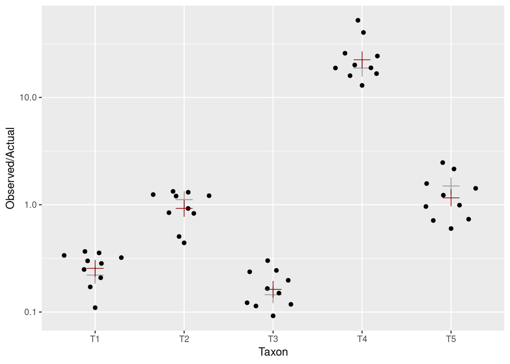

```r
p + geom_point(data = est1, aes(y=Bias_est.x), shape = 3, size = 5,
        color = "darkred")
```

This estimate is also the MLE under Aitchison’s logistic multivariate-normal error model, which corresponds to assuming the observed error after log-ratio transform to be multivariate normal. This is clear from the fact that we are simply computing the sample mean in log-ratio space, and we can check this directly by getting the MLE with the `mvnmle` package:

```r
tb <- exp1 %>%
    mutate(Observed_error = Observed / Actual) %>%
    select(Sample, Taxon, Observed_error) %>%
    mutate_by(Sample, Observed_error = clr(Observed_error)) %>%
    spread(Taxon, Observed_error) %>%
    select(-Sample)
fit <- mvnmle::mlest(tb, iterlim = 1000)
est1 <- est1 %>%
    mutate(Bias_est.z = fit$muhat %>% exp %>% center_elts)
est1
```

```
#> # A tibble: 5 x 5
#>   Taxon   Bias Bias_est.x Bias_est.y Bias_est.z
#>   <chr>  <dbl>      <dbl>      <dbl>      <dbl>
#> 1 T1     0.221      0.255      0.255      0.255
#> 2 T2     1.11       0.925      0.925      0.925
#> 3 T3     0.145      0.163      0.163      0.163
#> 4 T4    18.8       22.4       22.4       22.4
#> 5 T5     1.49       1.16       1.16       1.16
```

## Experiment where samples contain different taxa

```r
exp2 <- exp1 %>%
    mutate(
        Actual = Actual * rbernoulli(n(), p = 0.66),
        Observed = Actual * Bias * Noise
    )
exp2
```

```
#> # A tibble: 50 x 6
#>    Sample Taxon   Bias Actual Noise Observed
#>    <chr>  <chr>  <dbl>  <dbl> <dbl>    <dbl>
#>  1 S1     T1     0.221   0    1.29     0
#>  2 S1     T2     1.11    1.83 0.828    1.69
#>  3 S1     T3     0.145   0    1.36     0
#>  4 S1     T4    18.8     1.25 1.07    25.1
#>  5 S1     T5     1.49    0    0.645    0
#>  6 S10    T1     0.221   1.34 0.946    0.280
#>  7 S10    T2     1.11    0    0.454    0
#>  8 S10    T3     0.145   0    1.63     0
#>  9 S10    T4    18.8     1.07 2.15    43.1
#> 10 S10    T5     1.49    0    0.664    0
#> # … with 40 more rows
```

Note, we no longer center the abundance vectors, since the geometric means for samples without all taxa will be zero.

To visualize bias in a composition-independent manner, we instead can compute pairwise ratios:

```r
ratios <- crossing(Sample = samples, Taxon.x = taxa, Taxon.y = taxa) %>%
    filter( Taxon.x < Taxon.y) %>%
    left_join(exp2, by = c("Sample", "Taxon.x" = "Taxon")) %>%
    left_join(exp2, by = c("Sample", "Taxon.y" = "Taxon")) %>%
    mutate(Pair = paste(Taxon.x, Taxon.y, sep = ":"))
ratios <- ratios %>%
    filter(Actual.x, Actual.y) %>%
    mutate(
        Observed = Observed.x / Observed.y,
        Actual = Actual.x / Actual.y,
        Bias = Bias.x / Bias.y
    )
```

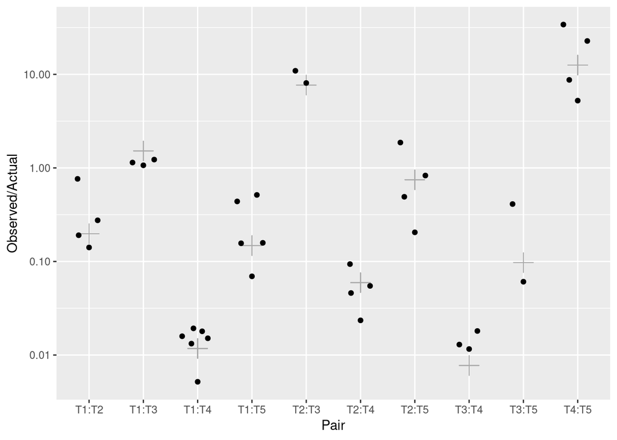

```r
p <- ggplot(ratios, aes(Pair, Observed / Actual)) +
    geom_point(aes(y=Bias), shape = 3, size = 5, color = "darkgrey") +
    geom_quasirandom() +
    scale_y_log10()
p
```

The “center” method of `estimate_bias` gives NaN’s because the compositional differences between the Observed and Actual abundance vectors contain elements with 0/0. But the “rss” method still gives a sensible answer.

```r
est2 <- bias %>%
    left_join(estimate_bias(exp2, method = "center"), by = "Taxon") %>%
    left_join(estimate_bias(exp2, method = "rss"), by = "Taxon")
est2
```

```
#> # A tibble: 5 x 4
#>   Taxon   Bias Bias_est.x Bias_est.y
#>   <chr>  <dbl>      <dbl>      <dbl>
#> 1 T1     0.221        NaN      0.240
#> 2 T2     1.11         NaN      0.976
#> 3 T3     0.145        NaN      0.184
#> 4 T4    18.8          NaN     18.6
#> 5 T5     1.49         NaN      1.25
```

We can check the fit by looking at the predicted error in the pairwise ratios,

```r
est2.1 <- est2 %>%
    select(Taxon, Bias_est = Bias_est.y)
ratios <- ratios %>%
    left_join(est2.1, by = c("Taxon.x" = "Taxon")) %>%
    left_join(est2.1, by = c("Taxon.y" = "Taxon")) %>%
    mutate(Bias_est = Bias_est.x / Bias_est.y)
```

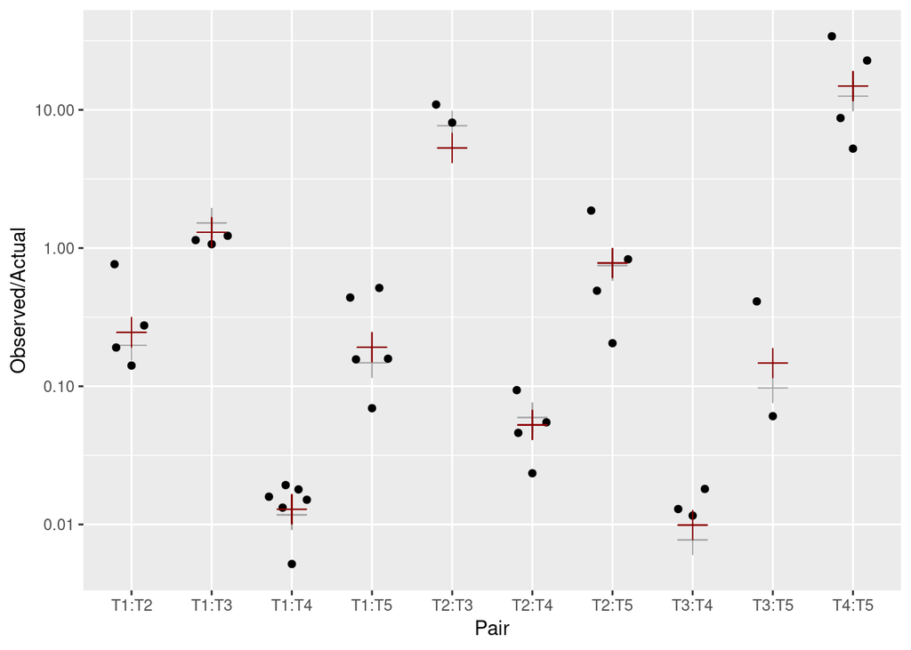

```r
p +
    geom_point(data = ratios, aes(y=Bias_est), shape = 3, size = 5,
        color = "darkred")
```

The `mvnmle` package can still be used to perform maximum likelihood estimation in this situation. Rather than computing the `clr`, we take the log of each taxon as if taking the `alr` to an imaginary reference taxon assumed to have an observed error (Observed/Actual) equal to 1.

```r
tb <- exp2 %>%
    mutate(Observed_error = Observed / Actual) %>%
    select(Sample, Taxon, Observed_error) %>%
    mutate_by(Sample, Observed_error = log(Observed_error)) %>%
    spread(Taxon, Observed_error) %>%
    select(-Sample)
tb
```

```
#> # A tibble: 10 x 5
#>         T1        T2      T3     T4       T5
#>      <dbl>     <dbl>   <dbl>  <dbl>    <dbl>
#>  1  NaN      -0.0798  NaN      3.00  NaN
#>  2   -1.57  NaN       NaN      3.70  NaN
#>  3  NaN       0.218    -2.17 NaN     NaN
#>  4   -1.00    0.287   NaN      3.19   -0.338
#>  5   -1.13  NaN        -1.20   2.81   -0.310
#>  6  NaN     NaN       NaN    NaN       0.352
#>  7   -1.39    0.268   NaN    NaN       0.455
#>  8   -1.09   -0.817   NaN      2.93    0.768
#>  9   -1.76    0.194    -1.90   2.56    0.905
#> 10   -1.20  NaN        -1.41   2.94  NaN
```

Under my understanding, the NaN’s will be treated as missing at random (MAR) and so not influence the likelihood (which is what we want).

```r
fit <- mvnmle::mlest(tb, iterlim = 1000)
est2 <- est2 %>%
    mutate(Bias_est.z = fit$muhat %>% exp %>% center_elts)
est2
```

```
#> # A tibble: 5 x 5
#>   Taxon   Bias Bias_est.x Bias_est.y Bias_est.z
#>   <chr>  <dbl>      <dbl>      <dbl>      <dbl>
#> 1 T1     0.221        NaN      0.240      0.229
#> 2 T2     1.11         NaN      0.976      0.986
#> 3 T3     0.145        NaN      0.184      0.189
#> 4 T4    18.8          NaN     18.6       17.9
#> 5 T5     1.49         NaN      1.25       1.31
```

This estimate differs somewhat from the “rss” result. It is also quite unstable for `iterlim` lower than ~1000 in this small dataset, and seems to become much more unstable in slightly larger datasets or datasets with more missing taxa, so I’m not sure if I trust the difference seen here.

## Experiment where samples have disjoint sets of taxa

```r
exp3 <- exp1 %>%
    mutate(
        Actual = case_when(
            Sample <= "S5" & Taxon <= "T3" ~ Actual,
            Sample <= "S5" & Taxon > "T3" ~ 0,
            Sample > "S5" & Taxon <= "T3" ~ 0,
            Sample > "S5" & Taxon > "T3" ~ Actual,
        ),
        Observed = Actual * Bias * Noise
    )
exp3
```

```
#> # A tibble: 50 x 6
#>    Sample Taxon   Bias Actual Noise Observed
#>    <chr>  <chr>  <dbl>  <dbl> <dbl>    <dbl>
#>  1 S1     T1     0.221  2.07  1.29    0.588
#>  2 S1     T2     1.11   1.83  0.828   1.69
#>  3 S1     T3     0.145  0.381 1.36    0.0753
#>  4 S1     T4    18.8    0     1.07    0
#>  5 S1     T5     1.49   0     0.645   0
#>  6 S10    T1     0.221  1.34  0.946   0.280
#>  7 S10    T2     1.11   0.206 0.454   0.104
#>  8 S10    T3     0.145  1.95  1.63    0.462
#>  9 S10    T4    18.8    0     2.15    0
#> 10 S10    T5     1.49   0     0.664   0
#> # … with 40 more rows
```

In this case, the 5 taxa form two sets, such that we can estimate the bias within sets but not between them, since there are no samples with taxa from both sets. The `estimate_bias` function’s “rss” method will still work, but we can’t trust the relative efficiencies between sets of taxa, only within sets:

```r
est3 <- bias %>%
    left_join(estimate_bias(exp3, method = "rss"), by = "Taxon") %>%
    mutate(Set = case_when(
            Taxon <= "T3" ~ "Set1",
            Taxon > "T3" ~ "Set2",
        ))
est3 <- est3 %>%
    mutate_by(Set,
        Bias.in_set = center_elts(Bias),
        Bias_est.in_set = center_elts(Bias_est)
    )
est3
```

```
#> # A tibble: 5 x 6
#>   Taxon   Bias Bias_est Set   Bias.in_set Bias_est.in_set
#>   <chr>  <dbl>    <dbl> <chr>       <dbl>           <dbl>
#> 1 T1     0.221    0.456 Set1        0.670           0.764
#> 2 T2     1.11     1.61  Set1        3.39            2.71
#> 3 T3     0.145    0.288 Set1        0.441           0.483
#> 4 T4    18.8      7.20  Set2        3.55            3.31
#> 5 T5     1.49     0.655 Set2        0.282           0.302
```